# si_analysis

Analysis for Scalar Implicature tablet task (Rose Schneider, Michael Frank). This study is an adaptation of the Scalar Implicature storybook game (Horowitz & Frank, 2015), and is a follow-up to Horowitz, Schneider, & Frank (in prep) to test the relationship between developmental changes in scalar implicature computatio, quantifier comprehension, and processing time. Participants saw 30 test trials with 3 book covers, each containing 4 familiar objects (e.g., book one: 4 cats, book two: 2 cats and 2 birds, book three: 4 dogs). Participants heard an audio prompt (“some/none/all of the pictures are cats”), and made their selection based on that prompt. Response times were recorded from the onset of the target word (i.e., “cats”). The planned sample is 96 3-5-year-olds, with 24 participants in each 6-month age bin.

## Set up

Load required libraries

```r
library(knitr)
opts_chunk$set(cache=TRUE, message=FALSE, warning=FALSE)
```

Preliminaries

```r
rm(list=ls())
library(ggplot2)
library(reshape)
library(plyr)
library(dplyr)
library(stringr)
library(tidyr)
library(markdown)
library(directlabels)
library(magrittr)
library(bootstrap)
library(RCurl)
library(langcog)
library(RColorBrewer)
library(diptest)
library(RWiener)
theme_set(theme_bw())
```

Load data.

```r
df <- read.csv("cdm_tablet_sample.csv")

#clean up data for analysis

#remove pilot 1 and 2 (1 for language, 2 for age range)
df %<>%
  mutate(age = as.numeric(age))%>%
  mutate(resp = factor(correct, levels=c("Y","N"), labels=c("upper","lower")),
         q = rt/1000)%>%
  filter(age <= 5)%>%
  mutate(age_round = round(age, digits = 2))%>%
  mutate(agesplit = cut(age_round, breaks=c(3, 3.5, 4, 4.5, 5)),
         agesplit = factor(agesplit,
                           labels=c("3-3.5 years", "3.5-4 years", "4-4.5 years", "4.5-5 years")))

df$correct %<>%
  str_replace("Y", 1)%>%
  str_replace("N", 0)

df %<>%
  mutate(correct = as.numeric(correct))

df$selection_type %<>%
  str_replace("allall", "all")
```

Weiner plot

```r
wiener.plot <- function (dat)
{
  rt = as.double(dat$q)
  rc = as.numeric(as.factor(dat$resp))
  dpos = tryCatch(density(rt[rc == 1], from = 0),error=function(e) NA)
  dneg = tryCatch(density(rt[rc == 2], from = 0),error=function(e) NA)
  maxt = max(pretty(max(rt)))

  maxd <- NA
  if(is.na(dpos[1])){
    maxd <- max(dneg$y)
  } else if(is.na(dneg[1])){
    maxd <- max(dpos$y)
  } else {
    maxd <- max(dpos$y, dneg$y)
  }

  par(mar = c(0, 5, 0, 0), mfcol = c(2, 1), ask = FALSE)
  plot(dpos, xlim = c(0, maxt), ylim = c(0, maxd), las = 2,
       lwd = 2, col = "green3", main = "", ylab = "", ask = FALSE)
  rug(rt[rc == 1], col = "green3")
  mtext("Density of positive responses", side = 2, line = 4,
        cex = 0.8)
  plot(dneg, xlim = c(0, maxt), ylim = c(maxd, 0), las = 2,
       lwd = 2, col = "red", main = "", ylab = "", ask = FALSE)
  mtext("Density of negative responses", side = 2, line = 4,
        cex = 0.8)
  rug(rt[rc == 2], col = "red", side = 3)
}
```

# How many children are in each age bin?

```r
num_kids <- df %>%
  dplyr::select(sub_id, agesplit) %>%
  dplyr::distinct() %>%
  dplyr::group_by(agesplit)%>%
  dplyr::summarize(n=n())%>%
  dplyr::mutate(total.n = sum(n))
```

# Overall analysis: Performance by age

Mean performance with 95% confidence intervals over all trial types

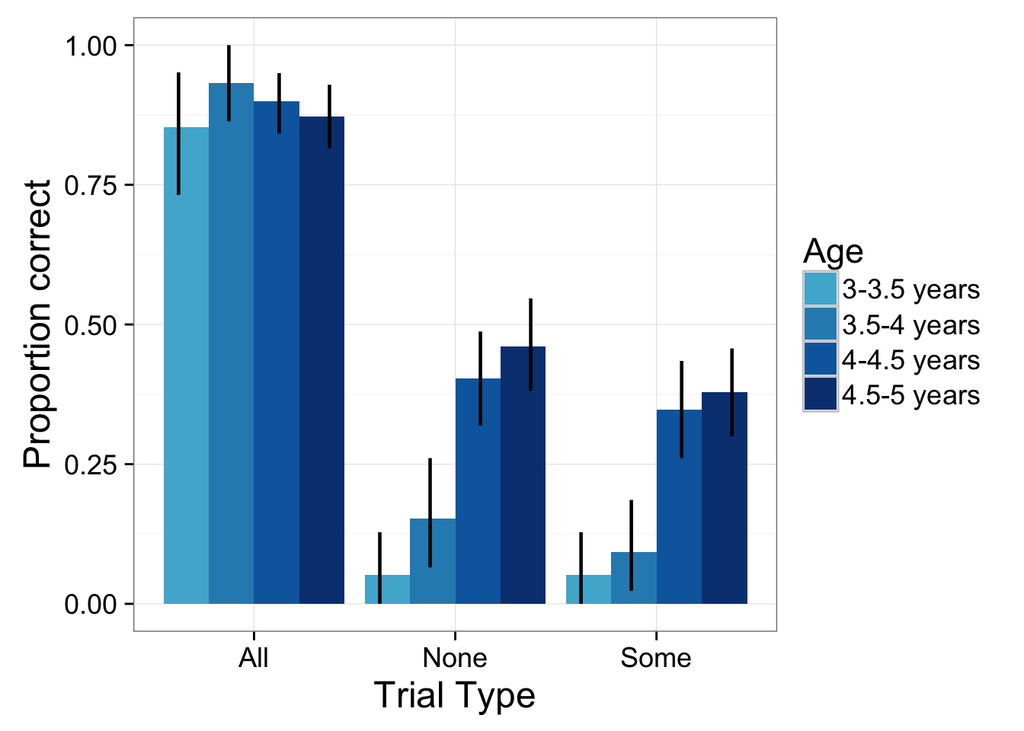

```r
ms <- df %>%
  group_by(trial_type, agesplit)%>%
  multi_boot_standard("correct", na.rm=T)

ms$trial_type %<>%
  str_replace("all", "All")%>%
  str_replace("none", "None")%>%
  str_replace("some", "Some")

quartz()
ggplot(data = ms,
       aes(x=trial_type, y=mean, fill= agesplit)) +
  geom_bar(stat="identity", position = position_dodge()) +
  geom_linerange(aes(ymin = ci_lower,
                      ymax = ci_upper),
                  size = .8,
                  show.legend = FALSE,
                 position=position_dodge(1)) +
  ylab("Proportion correct") +
  xlab("Trial Type") +
  theme_bw(base_size = 17) + theme(axis.title.x = element_text(size=18),
           axis.title.y  = element_text(size=18)) +
  scale_fill_manual(values = c("#4EB3D3", "#2B8CBE", "#0868AC", "#084081"),
                    name="Age")
```

## Proportion correct by sub_id (initial analysis)

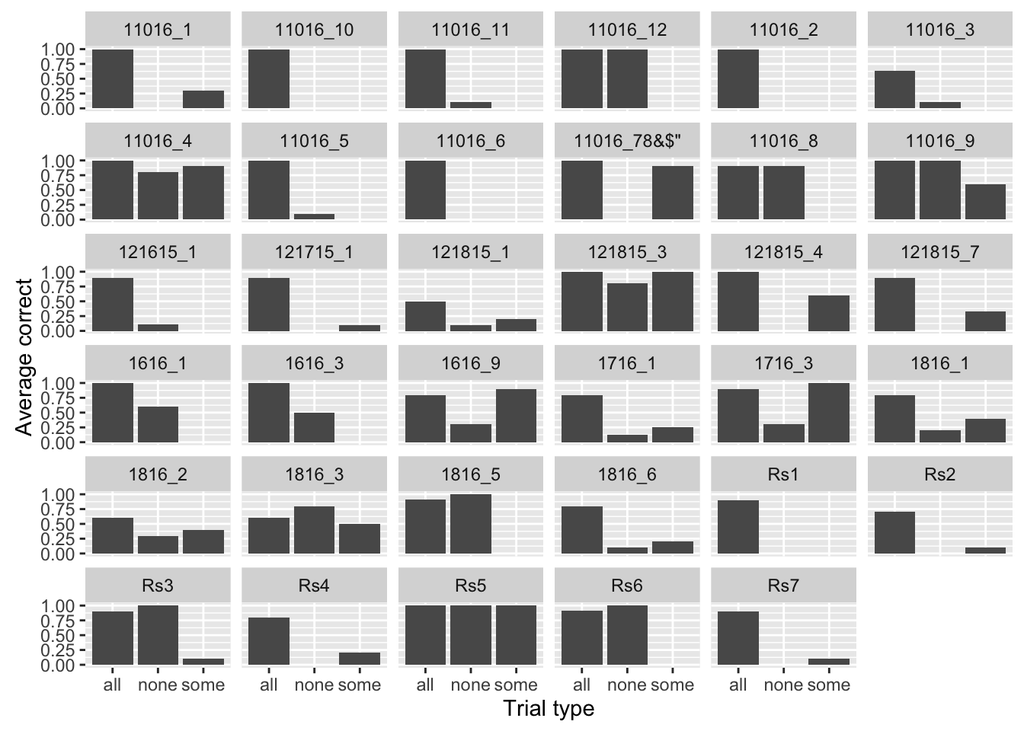

```r
ms <- df %>%
  group_by(trial_type, sub_id)%>%
  multi_boot_standard("correct", na.rm=T)

quartz()
ggplot(data = ms,
       aes(x=trial_type, y=mean)) +
  geom_bar(stat="identity", position = "dodge") + ylab("Average correct") + xlab("Trial type") + facet_wrap(~sub_id)
```

## Histogram of correct response for trial types

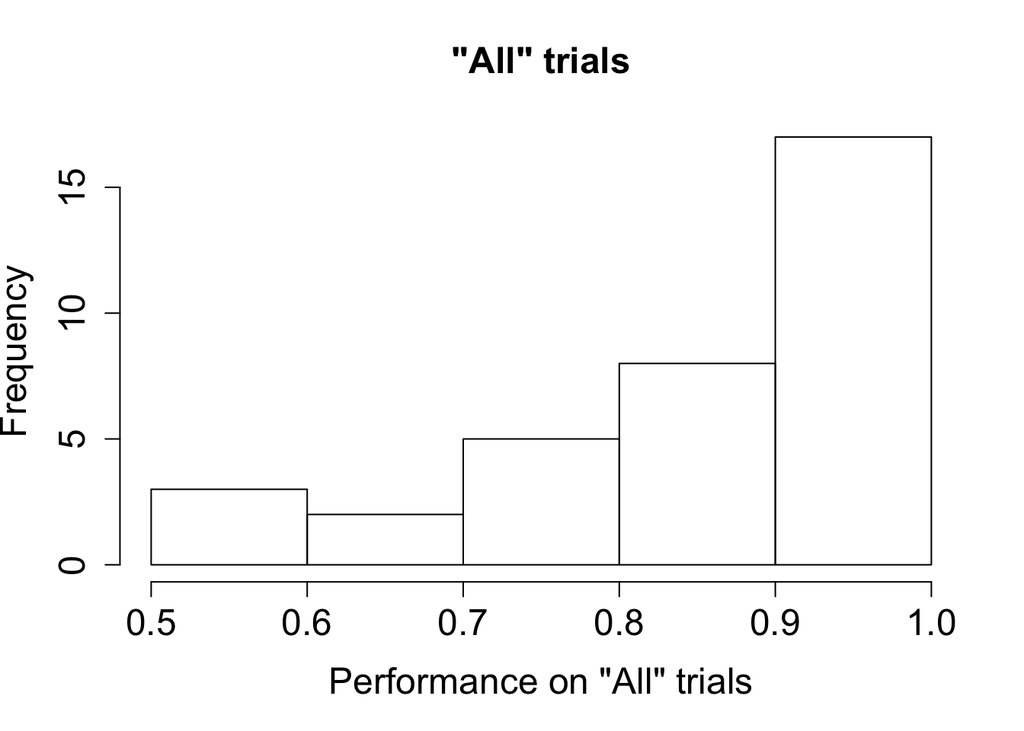

```r
#all
all.hist <- df %>%
  filter(trial_type == "all")%>%
  group_by(sub_id)%>%
  mutate(correct=as.numeric(correct))%>%
  summarise(mean = mean(correct))

quartz()
hist(all.hist$mean, main = paste('"All" trials'), xlab = 'Performance on "All" trials', cex.lab=1.5, cex.axis=1.5, cex.main=1.5, cex.sub=1.5)
```

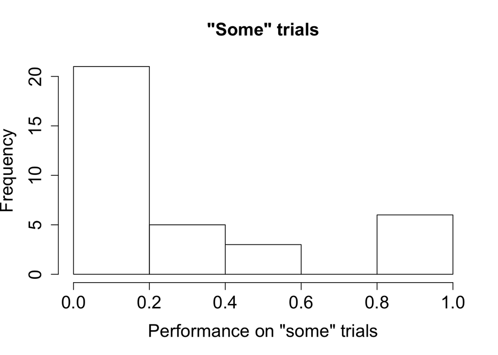

```r
#some
some.hist <- df %>%
  filter(trial_type == "some")%>%
  group_by(sub_id)%>%
  mutate(correct=as.numeric(correct))%>%
  summarise(mean = mean(correct))

quartz()
hist(some.hist$mean, main = paste('"Some" trials'), xlab = 'Performance on "some" trials', cex.lab=1.5, cex.axis=1.5, cex.main=1.5, cex.sub=1.5)
```

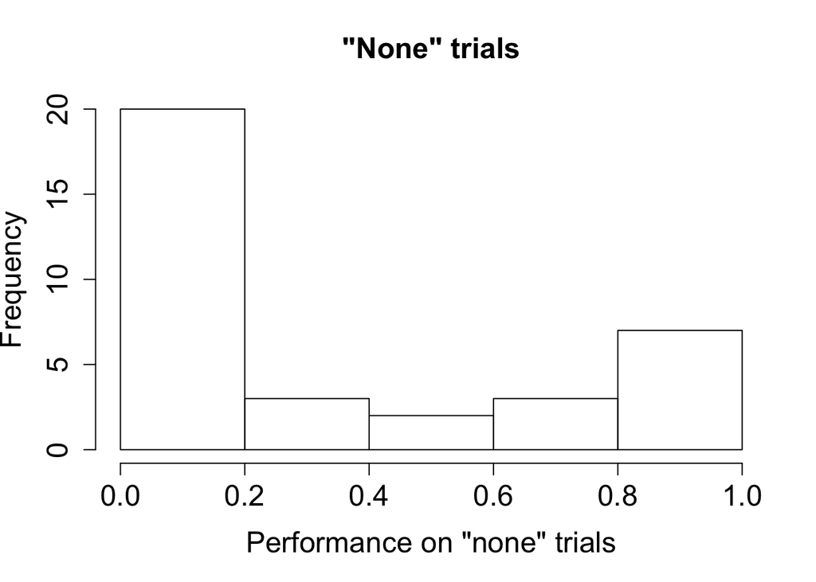

```r
#none
none.hist <- df %>%
  filter(trial_type == "none")%>%
  group_by(sub_id)%>%
  mutate(correct=as.numeric(correct))%>%
  summarise(mean = mean(correct))

quartz()
hist(none.hist$mean, main = paste('"None" trials'), xlab = 'Performance on "none" trials', cex.lab=1.5, cex.axis=1.5, cex.main=1.5, cex.sub=1.5)
```

## Dip-test analysis

```r
ms <- ddply(df, .(trial_type, sub_id), summarise,
    mean = mean(correct),
    Age = age[1])

cs <- cast(ms, sub_id + Age ~ trial_type, value="mean")

diptest::dip.test(cs$some)
```

```
##
##  Hartigans' dip test for unimodality / multimodality
##
## data:  cs$some
## D = 0.064286, p-value = 0.2989
## alternative hypothesis: non-unimodal, i.e., at least bimodal
```

```r
diptest::dip.test(cs$none)
```

```
##
##  Hartigans' dip test for unimodality / multimodality
##
## data:  cs$none
## D = 0.093878, p-value = 0.01166
## alternative hypothesis: non-unimodal, i.e., at least bimodal
```

```r
diptest::dip.test(cs$all)
```

```
##
##  Hartigans' dip test for unimodality / multimodality
##
## data:  cs$all
## D = 0.11688, p-value = 0.0002984
## alternative hypothesis: non-unimodal, i.e., at least bimodal
```

## Response time analyses

Do children take longer to respond when they get trials correct?

Data cleaning Currently trying out a few possibilities, trying to figure out which makes the most sense

```r
#first, find summary stats of each quantifier type
df %<>%
  mutate(rt = as.numeric(rt))

df.rt <- df %>%
  group_by(trial_type)%>%
  summarise(mean = mean(rt), sd = sd(rt), max = max(rt), min = min(rt), median=median(rt))%>%
  group_by(trial_type)
```

Visual distributions of RTs for each quantifier type

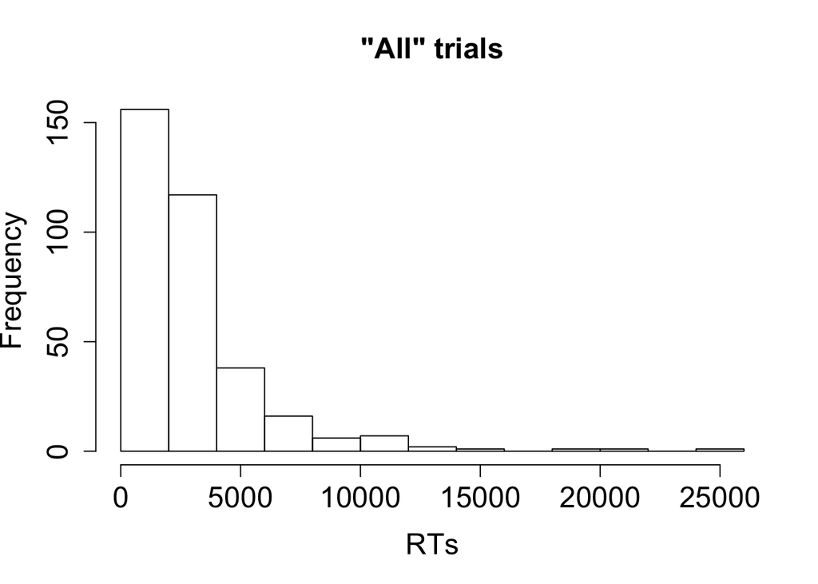

```r
#visual distribution of response times for each quantifier
#All
all_hist <- df %>%
  filter(trial_type == "all")%>%
  group_by(sub_id)

quartz()
hist(all_hist$rt, main = paste('"All" trials'), xlab = 'RTs', cex.lab=1.5, cex.axis=1.5, cex.main=1.5, cex.sub=1.5)
```

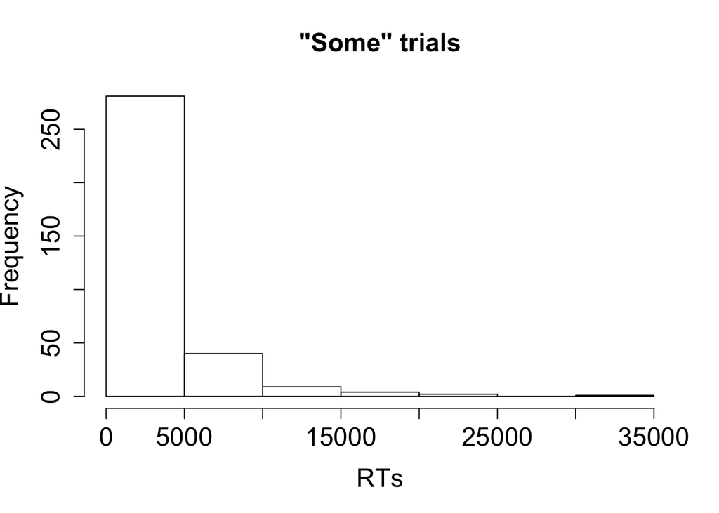

```r
#Some
some_hist <- df %>%
  filter(trial_type == "some")%>%
  group_by(sub_id)

quartz()
hist(some_hist$rt, main = paste('"Some" trials'), xlab = 'RTs', cex.lab=1.5, cex.axis=1.5, cex.main=1.5, cex.sub=1.5)
```

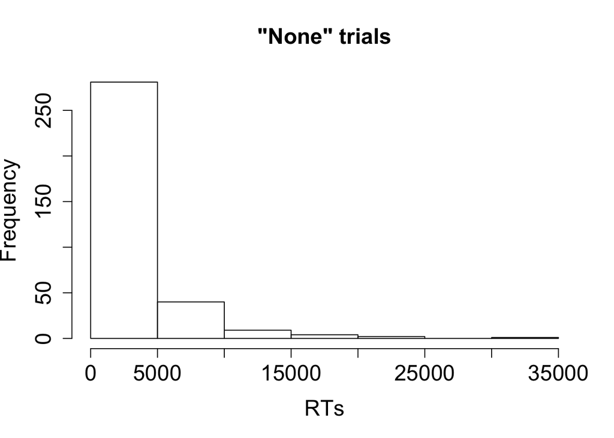

```r
#None
none_hist <- df %>%
  filter(trial_type == "none")%>%
  group_by(sub_id)

quartz()
hist(some_hist$rt, main = paste('"None" trials'), xlab = 'RTs', cex.lab=1.5, cex.axis=1.5, cex.main=1.5, cex.sub=1.5)
```

This is an option for removing plus and minus one sd - not effective right now, as data is sparse

```r
# hist_all <- df %>%
#   filter(trial_type == "all")
#
# df.all <- df.rt %>%
#   filter(trial_type == "all")
#
# df.some <- df.rt %>%
#   filter(trial_type == "some")
#
# df.none <- df.rt %>%
#   filter(trial_type == "none")
#
# ms.all <- df %>%
#   mutate(half = cut(trial_num, breaks=c(0, 15, 30)),
#           half = factor(half,
#                             labels=c("First", "Second")))%>%
#   mutate(correct = as.factor(correct))%>%
#   group_by(trial_type, agesplit, correct)%>%
#   filter(trial_type == "all")%>%
#   filter(rt >= df.all$lower | rt <= df.all$upper)
#
# ms.some <- df %>%
#   mutate(half = cut(trial_num, breaks=c(0, 15, 30)),
#           half = factor(half,
#                             labels=c("First", "Second")))%>%
#   mutate(correct = as.factor(correct))%>%
#   group_by(trial_type, agesplit, correct)%>%
#   filter(trial_type == "some")%>%
#   filter(rt >= df.some$lower | rt <= df.some$upper)
#
# ms.none <- df %>%
#   mutate(half = cut(trial_num, breaks=c(0, 15, 30)),
#           half = factor(half,
#                             labels=c("First", "Second")))%>%
#   mutate(correct = as.factor(correct))%>%
#   group_by(trial_type, agesplit, correct)%>%
#   filter(trial_type == "none")%>%
#   filter(rt >= df.none$lower | rt <= df.none$upper)
#
# tmp <- rbind(ms.some, ms.all)
#
# #final dataframe with cleaned rts
# ms.rt <- rbind(ms.none, tmp)
```

RT analysis with plus and minus one sd removed

```r
# df %<>%
#   mutate(correct = as.factor(correct))
#
# mss <- ms.rt %>%
#   group_by(trial_type, correct, agesplit)%>%
#   multi_boot_standard("rt", na.rm=T)
#
# ggplot(data = mss,
#        aes(x=trial_type, y=mean, fill=correct)) +
#   geom_bar(stat="identity", position = "dodge") +
#   geom_linerange(aes(ymin = ci_lower,
#                       ymax = ci_upper),
#                   size = .8,
#                   show_guide = FALSE,
#                  position=position_dodge(1)) +
#   ylab("Mean RT (ms)") +
#   xlab("Trial Type") + facet_wrap(~agesplit)
```

This is an option with log-transformed values, and filtering plus/minus 2sd

```r
df.rt.log <- df %>%
  mutate(correct = as.factor(correct))%>%
  filter(log(rt) < mean(log(rt) + 2 * sd(log(rt))),
         log(rt) > mean(log(rt) - 2 * sd(log(rt))))

mss <- df.rt.log %>%
  group_by(trial_type, correct, agesplit)%>%
  multi_boot_standard("rt", na.rm = T)
```

RT analysis with log-transformed values

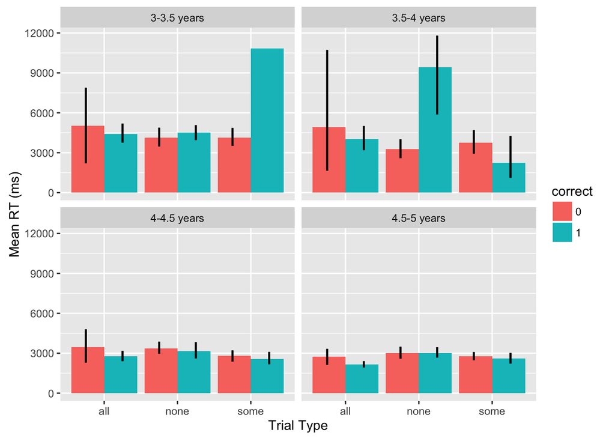

```r
quartz()
ggplot(data = mss,
       aes(x=trial_type, y=mean, fill=correct)) +
  geom_bar(stat="identity", position = "dodge") +
  geom_linerange(aes(ymin = ci_lower,
                      ymax = ci_upper),
                  size = .8,
                  show.legend = FALSE,
                 position=position_dodge(1)) +
  ylab("Mean RT (ms)") +
  xlab("Trial Type") + facet_wrap(~agesplit)
```

What about over the course of the study? Kids may be getting faster as they go through the task

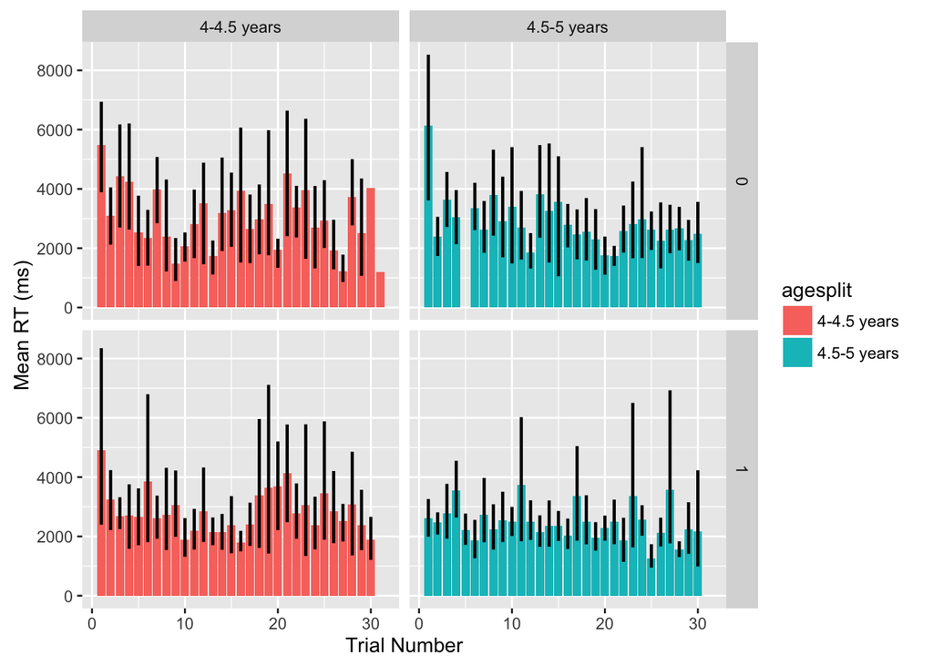

```r
#first, look at the distribution of RTs over trials
rt.dist <- df.rt.log %>%
  filter(agesplit == "4-4.5 years" | agesplit == "4.5-5 years")%>%
  mutate(correct = as.factor(correct))%>%
  group_by(trial_num, agesplit, correct)%>%
  multi_boot_standard("rt", na.rm = T)

#visual
ggplot(data = rt.dist,
       aes(x=trial_num, y=mean, fill=agesplit)) +
  geom_bar(stat="identity", position = "dodge") +
  geom_linerange(aes(ymin = ci_lower,
                      ymax = ci_upper),
                  size = .8,
                  show.legend = FALSE,
                 position=position_dodge(1)) +
  ylab("Mean RT (ms)") +
  xlab("Trial Number") + facet_grid(correct~agesplit)
```

```r
#compare the distributions between the correct and incorrect rts
```

Are there correlations between RT and getting the trial right?

```r
ms.rt <- ddply(df, .(trial_type, sub_id), summarise,
    mean = mean(rt),
    age = agesplit[1])

cs.rt <- cast(ms.rt, sub_id + age ~ trial_type, value="mean")

names(cs.rt) <- c("sub_id", "age", "rt_all", "rt_none", "rt_some")

ms <- ddply(df, .(trial_type, sub_id), summarise,
    mean = mean(correct),
    age = agesplit[1])

names(ms) <- c("type", "sub_id", "mean", "Age")

cs <- cast(ms, sub_id + Age ~ type, value="mean")

cs %<>%
  select(-Age)

cs.all <- full_join(cs, cs.rt, by = "sub_id")

cor.test(cs.all$rt_all, cs.all$all)
```

```
##
##  Pearson's product-moment correlation
##
## data:  cs.all$rt_all and cs.all$all
## t = 0.70413, df = 33, p-value = 0.4863
## alternative hypothesis: true correlation is not equal to 0
## 95 percent confidence interval:
##  -0.2205249  0.4371841
## sample estimates:
##       cor
## 0.1216626
```

```r
cor.test(cs.all$rt_some, cs.all$some)
```

```
##
##  Pearson's product-moment correlation
##
## data:  cs.all$rt_some and cs.all$some
## t = -1.4009, df = 33, p-value = 0.1706
## alternative hypothesis: true correlation is not equal to 0
## 95 percent confidence interval:
##  -0.5284446  0.1045834
## sample estimates:
##        cor
## -0.2369203
```

```r
cor.test(cs.all$rt_none, cs.all$none)
```

```
##
##  Pearson's product-moment correlation
##
## data:  cs.all$rt_none and cs.all$none
## t = -0.65848, df = 33, p-value = 0.5148
## alternative hypothesis: true correlation is not equal to 0
## 95 percent confidence interval:
##  -0.4307789  0.2280194
## sample estimates:
##        cor
## -0.1138806
```

Individual differences graphs

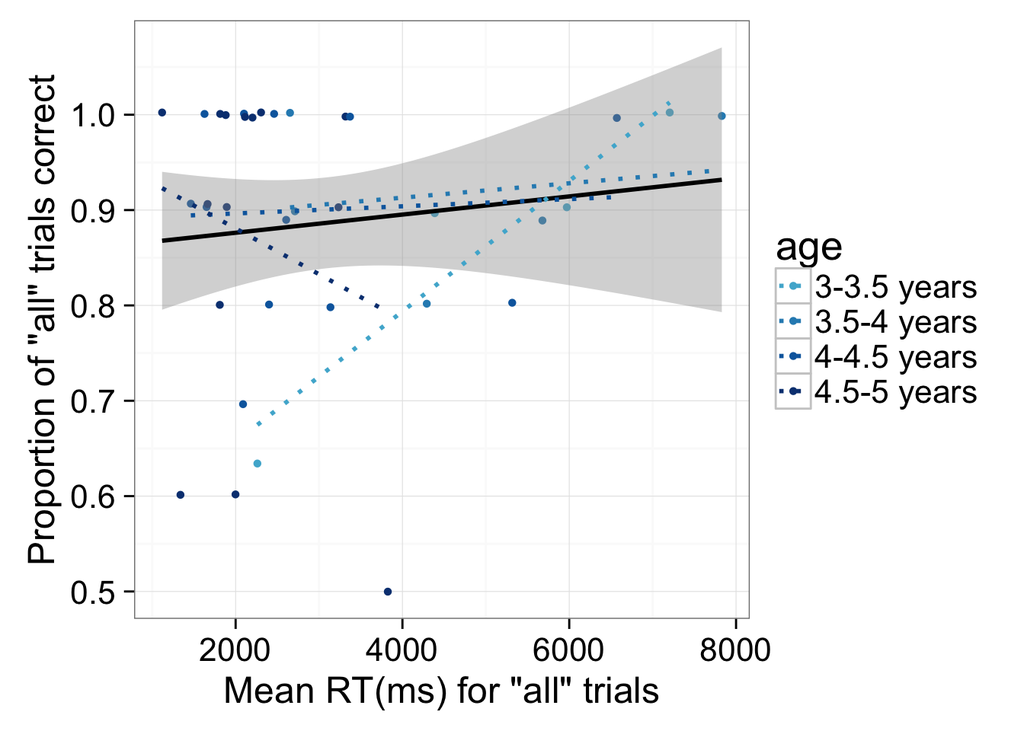

```r
#individual differences graph - all
quartz()
ggplot(cs.all, aes(x=rt_all, y=all, colour=age)) +
  geom_point(stat = "identity", position = position_jitter(.02), shape=16) +
  geom_smooth(method="lm", col="black", lty=1) +
  geom_smooth(aes(col=age, group=age),
                se=FALSE, method="lm",lty=3) + scale_colour_manual(values = c("#4EB3D3", "#2B8CBE", "#0868AC", "#084081")) + theme_bw(base_size=20) + theme(axis.title.y = element_text(size = 18),
                                      axis.title.x = element_text(size = 18)) +
  labs(x = 'Mean RT(ms) for "all" trials', y = 'Proportion of "all" trials correct')
```

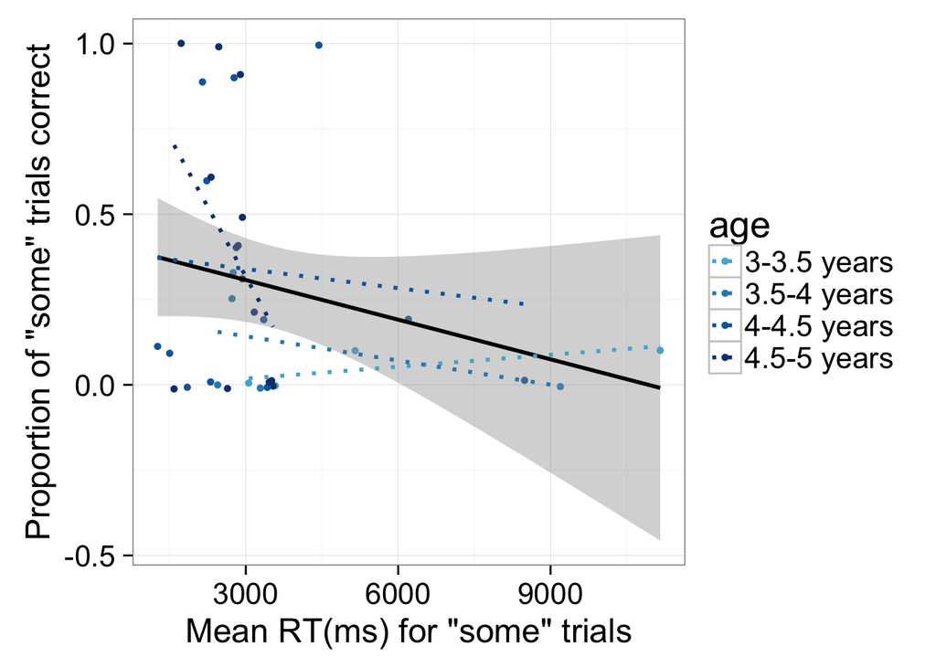

```r
#some
quartz()
ggplot(cs.all, aes(x=rt_some, y=some, colour=age)) +
  geom_point(stat = "identity", position = position_jitter(.02), shape=16) +
  geom_smooth(method="lm", col="black", lty=1) +
  geom_smooth(aes(col=age, group=age),
                se=FALSE, method="lm",lty=3) + scale_colour_manual(values = c("#4EB3D3", "#2B8CBE", "#0868AC", "#084081")) + theme_bw(base_size=20) + theme(axis.title.y = element_text(size = 18),
                                      axis.title.x = element_text(size = 18)) +
  labs(x = 'Mean RT(ms) for "some" trials', y = 'Proportion of "some" trials correct')
```

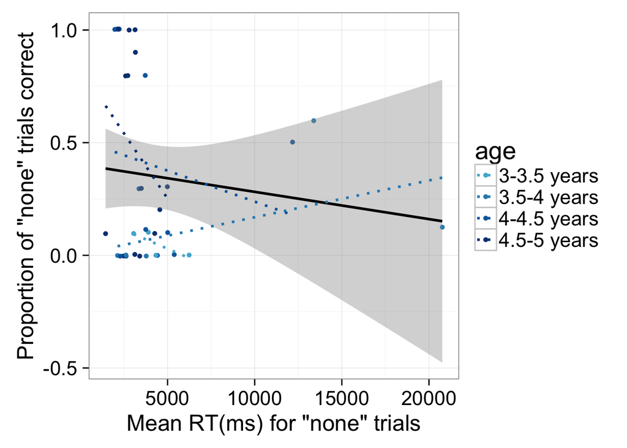

```r
#none
quartz()
ggplot(cs.all, aes(x=rt_none, y=none, colour=age)) +
  geom_point(stat = "identity", position = position_jitter(.02), shape=16) +
  geom_smooth(method="lm", col="black", lty=1) +
  geom_smooth(aes(col=age, group=age),
                se=FALSE, method="lm",lty=3) + scale_colour_manual(values = c("#4EB3D3", "#2B8CBE", "#0868AC", "#084081")) + theme_bw(base_size=20) + theme(axis.title.y = element_text(size = 18),
                                      axis.title.x = element_text(size = 18)) +
  labs(x = 'Mean RT(ms) for "none" trials', y = 'Proportion of "none" trials correct')
```

RT analysis

```r
# #Split by first half and second half of experiment (at least now), because they get much faster as the study goes on
# mss <- ms.rt %>%
#   group_by(trial_type, half, agesplit, correct)%>%
#   multi_boot_standard("rt", na.rm=T)
#
# quartz()
# ggplot(data = mss,
#        aes(x=trial_type, y=mean, fill=correct)) +
#   geom_bar(stat="identity", position = "dodge") +
#   geom_linerange(aes(ymin = ci_lower,
#                       ymax = ci_upper),
#                   size = .8,
#                   show_guide = FALSE,
#                  position=position_dodge(1)) +
#   ylab("Mean RT (ms)") +
#   xlab("Trial Type") + scale_fill_manual(values = c("#4EB3D3", "#2B8CBE")) + facet_grid(agesplit~half)
```

## Selections on incorrect trials

[figure not shown]

```r
wrong <- df %>%
  filter(correct == "0", selection_type != "someall")%>%
  group_by(trial_type, selection_type)%>%
  dplyr::summarise(n=n())%>%
  mutate(n.total = sum(n), prop = n/n.total)

ggplot(data = wrong,
       aes(x=selection_type, y=n)) +
  geom_bar(stat="identity", position = position_dodge())  +
  ylab("Count of children choosing") +
  xlab("Selection Type") + facet_wrap(~trial_type) + theme_bw(base_size=17) +
  theme(axis.title.x = element_text(size=18),
        axis.title.y = element_text(size=18)) + facet_wrap(~trial_type)
```

Diffusion

```
## [1] "Plot of all, kids"
```

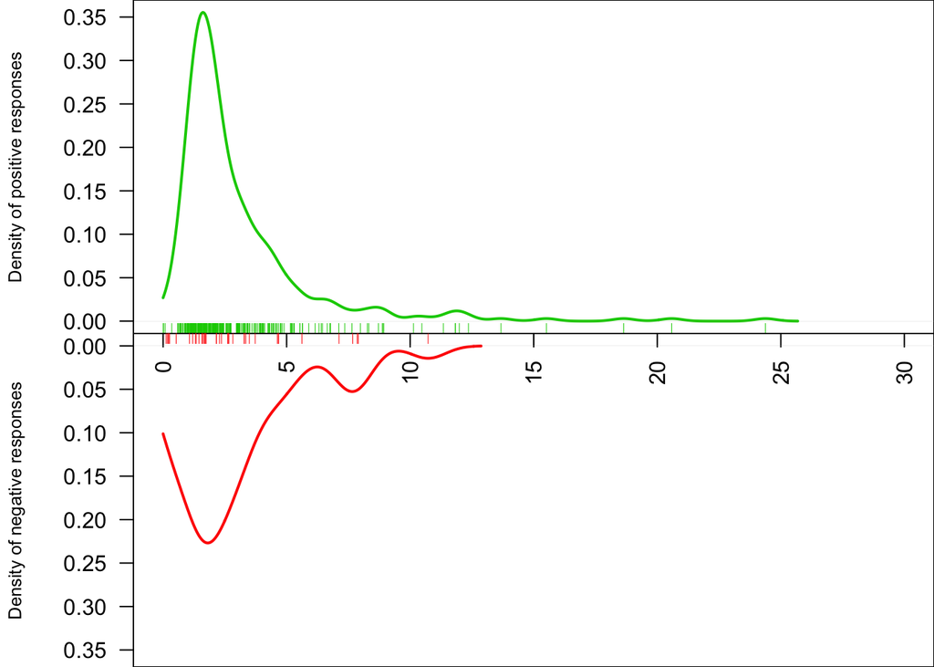

```
## [1] "Plot of some, kids"
```

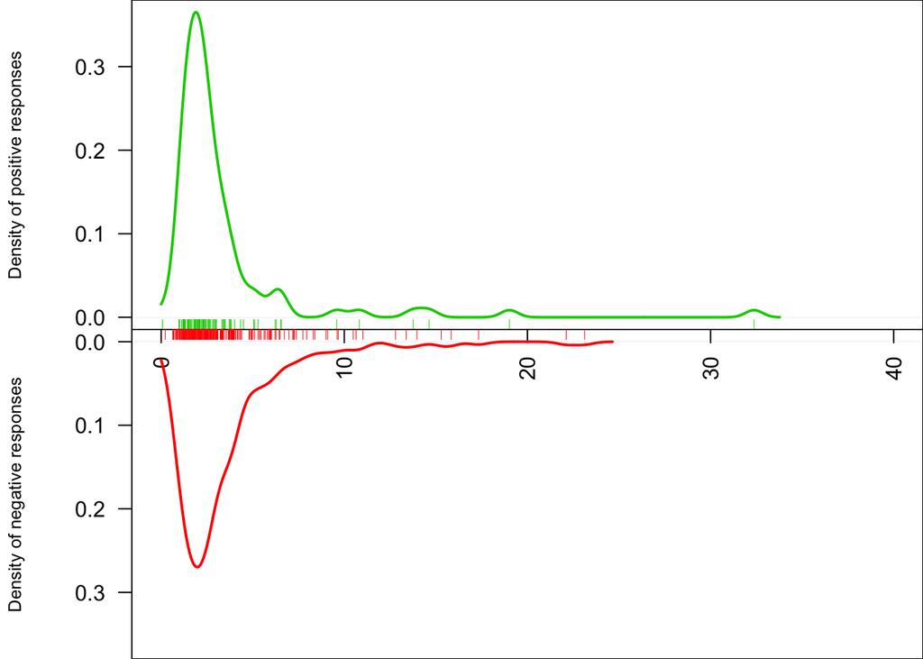

```
## [1] "Plot of none, kids"
```

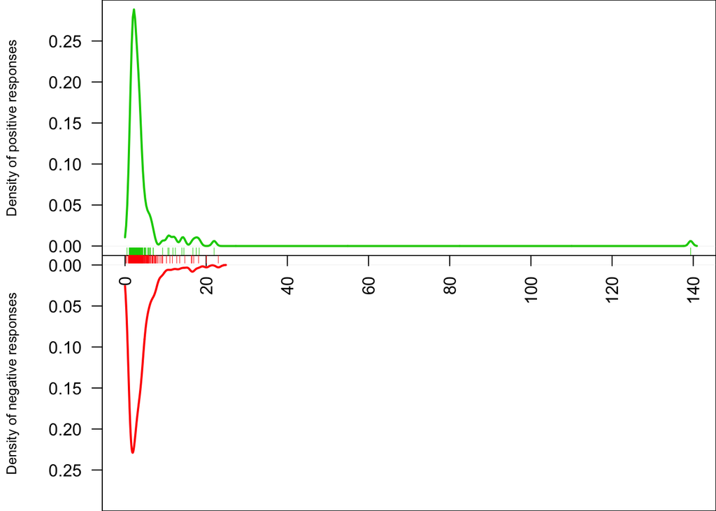

```r
trialtypes <- c("all", "some", "none")

for (i in 1:length(trialtypes)) {
  print(paste("Plot of ",trialtypes[i],", kids", sep=""))
  wiener.plot(subset(df, trial_type == trialtypes[i], select=c(q, resp)))
}
```

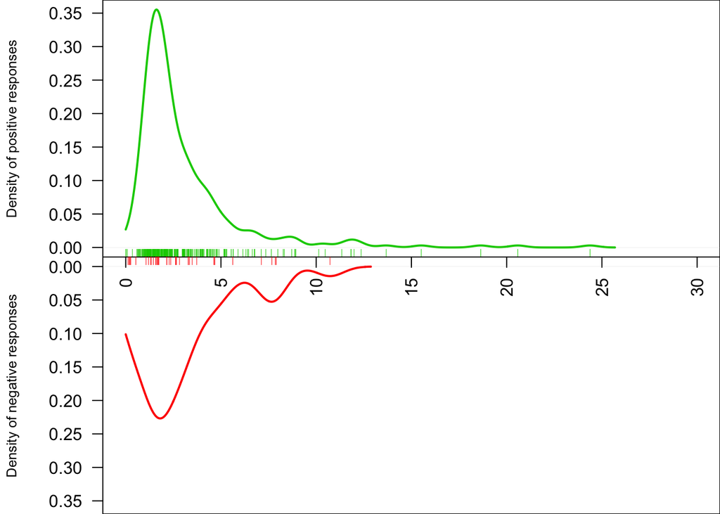

```r
wiener.plot(subset(df, trial_type == "all", select=c(q, resp)))
```

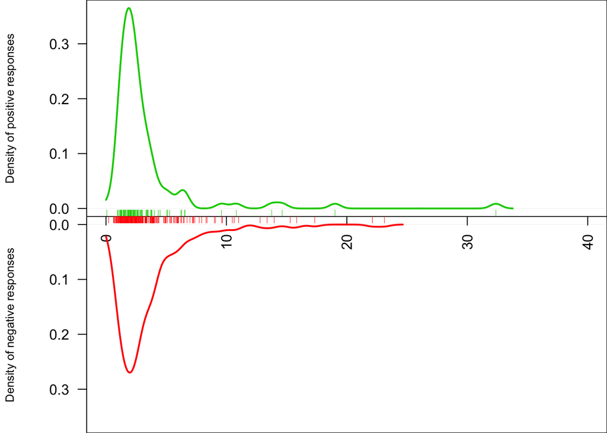

```r
quartz()
wiener.plot(subset(df, trial_type == "some", select=c(q, resp)))
```

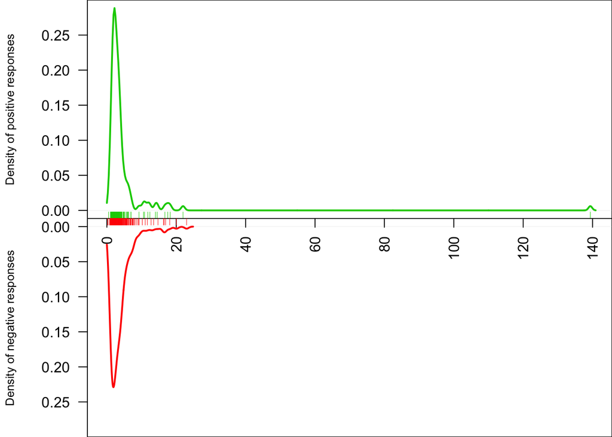

```r
wiener.plot(subset(df, trial_type == "none", select= c(q,resp)))
```

Planned analyses: 1. Developmental differences in accuracy (replication of previous work) 2. RTs in general for correct/incorrect choices 3. Diffusion model analysis: RT as a measure of processing time